# Lab 1: Introduction to Quarto

Author

Quinton Wong

Published

January 12, 2025

# Part Two: Exploring Quarto Documents

## Specifying Global Execute Options

Execution options specify how the R code in your Quarto document should be displayed. This [guide](https://quarto.org/docs/computations/execution-options.html) provides descriptions on the options you can specify in a document’s execution.

**Question 1** – Add your name and the date to the YAML.

**Question 2** – Add an `execute` line to your YAML that includes the following options, (1) your source code is always output on the page, and (2) your document will render even if there are errors.

## Tooth Growth Dataset

```r
# Load a dataset into the R Environment.
data(ToothGrowth)

# Look at the summary of the variables in the dataset.
summary(ToothGrowth)
```

[output not shown]

**Question 3** – Let’s spice this code up a bit. Delete `1 + 1` from the code chunk and paste in the code provided in the Lab 1 instructions.

### Check the Data Documentation

**Question 4** – In your **console** (*not* in the Quarto document), type `?ToothGrowth` (or alternatively `help(ToothGrowth)`.Use the information that pops up in the *Help* pane in RStudio to fill in the blanks below.

*This dataset investigates the effect of Vitamin C on tooth growth in guinea pigs.*

*The two supplement delivery methods include OJ (orange juice) and VC (ascorbic acid).*

*`ToothGrowth` is a data frame with 60 observations and 3 variables.*

**Question 5** – *Before* the code chunk, change the “Running the Provided Code” section header to a header that better describes the contents of this section (e.g., Tooth Growth Dataset).

## Creating a Plot

**Question 6** – Replace the `plot(pressure)` code with the code provided in the Lab 1 instructions.

```r
library(tidyverse)
```

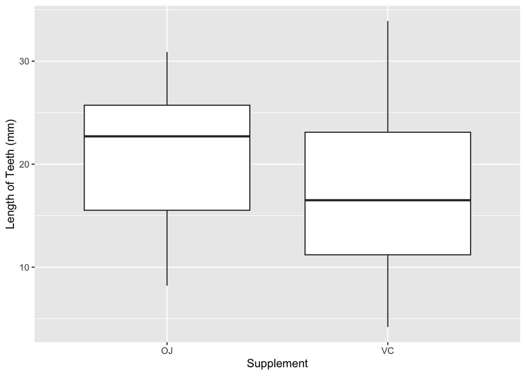

Box plot comparing tooth length between supplement delivery methods

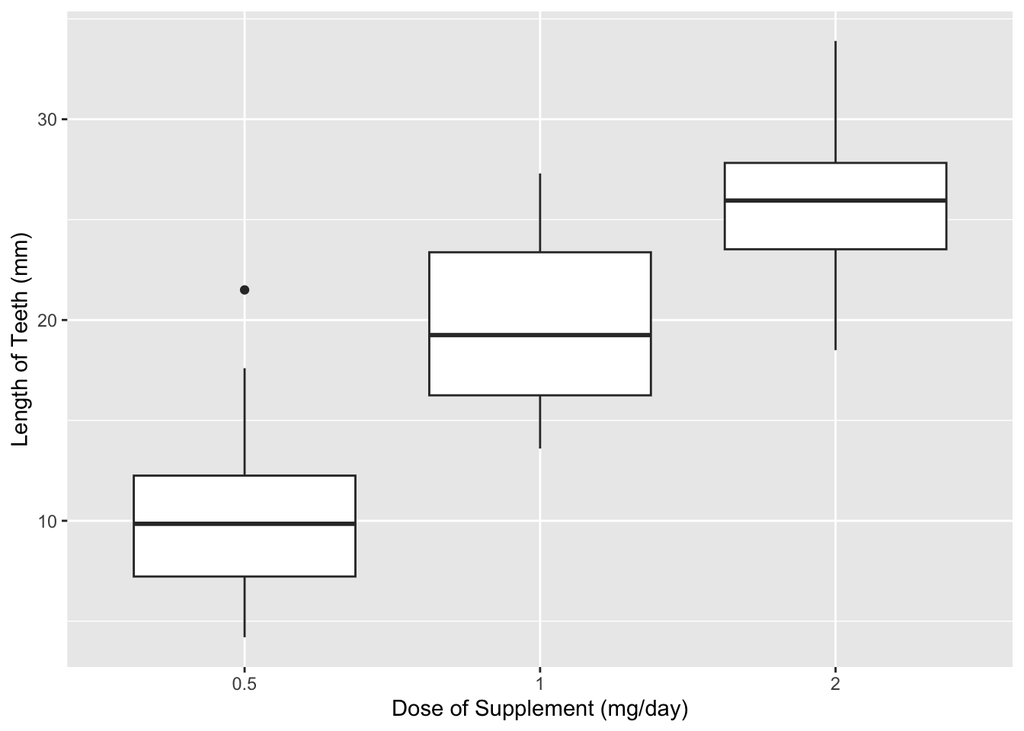

Box plot comparing tooth length between dosages uses

```r
ggplot(data = ToothGrowth,
       mapping = aes(x = supp, y = len)) +
  geom_boxplot() +
  labs(x = "Supplement", y = "Length of Teeth (mm)")
ToothGrowth %>%
  mutate(dose = as.factor(dose)) %>%
  ggplot(mapping = aes(x = dose, y = len)) +
  geom_boxplot() +
  labs(x = "Dose of Supplement (mg/day)", y = "Length of Teeth (mm)")
```

Now, run this code chunk! You should see two side-by-side boxplots, one plot comparing tooth length between the two supplement delivery methods and one plot comparing tooth length between the three different dosages uses.

**Question 7** – Read over the [Quarto documentation on figure options](https://quarto.org/docs/authoring/figures.html#computations) and add an option (`#|`) to the above code chunk to make the figures print side-by-side (i.e., in one row) in the rendered HTML file.

**Question 8** – Specify in the code chunk options that these boxplots should be **center aligned**.

**Question 9** – Specify a **figure caption** for the boxplots (using a code-chunk option).

## Two-sample independent t-test comparing tooth length between OJ & VC supplement delivery methods

```r
t.test(len ~ supp, data = ToothGrowth, alternative = "two.sided", var.equal = FALSE)
```

```
    Welch Two Sample t-test

data:  len by supp
t = 1.9153, df = 55.309, p-value = 0.06063
alternative hypothesis: true difference in means between group OJ and group VC is not equal to 0
95 percent confidence interval:
 -0.1710156  7.5710156
sample estimates:
mean in group OJ mean in group VC
        20.66333         16.96333
```

1. Given the p-value of 0.06063 and assuming a significance level of 0.05, we fail to reject the null hypothesis that the treatment mean tooth length for the OJ supplement delivery method is the same as the treatment mean tooth length from the VC supplement delivery method. This means that we lack sufficient evidence to find a statistically significant difference in treatment mean tooth length between the OJ and VC supplement delivery methods given a significance level of 0.05.
2. With a default confidence level of 95 percent, this means that we are 95 percent confident that the true difference in treatment mean tooth lengths between OJ and VC supplement delivery methods lies within the interval of (-0.1710156, 7.5710156). Since the value of 0 lies within this interval, the difference between the treatment mean tooth lengths could be 0, which further supports our failure to reject the null hypothesis.